# Part II - (Prosper Loan Analysis)

## by (Blessing Olayemi)

## Investigation Overview

The key insights of my presentation after my exploration analysis are as follows

1. The demography of the borrowers.
2. The employment status and ocupation of the borrowers.
3. The ratio of homeowners to non home owners amongst the borrowers.
4. The debt to income ratio.
5. Relationship between income range and loan term
6. The distribution of borrower's annual percentage rate.
7. The difference between loan amount accessible to home ownwers and non-home owners.

## Dataset Overview

> The dataset is a loan dataset originally from kaggle. it is called the prosper loan dataset. It belongs to a San Francisco based company that is involved in peer-to-peer lending. The dataset consists of 113,937 loans with over 81 variables on each loan.

## (Visualization 1)

### Borrower's Demography

> The borrower's demography will be limited to the first ten states.

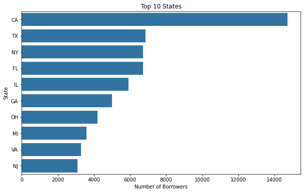

## (Visualization 2)

### Percentage of Home Owners to Non-Home Owners

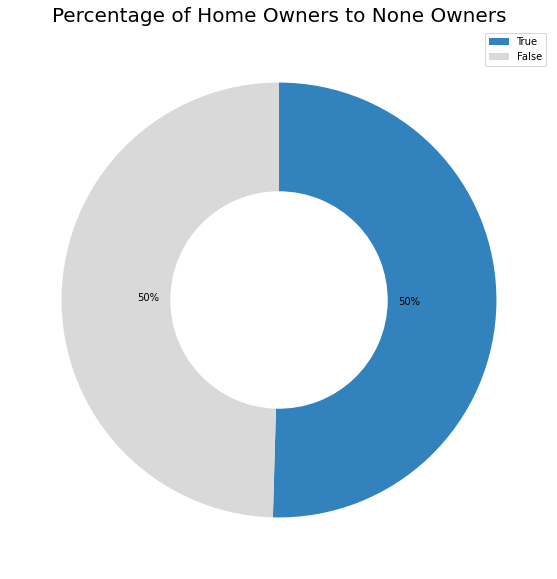

> It can be observed that there is a 50:50 ratio of home owners to non-home owners among the borrowers.

## (Visualization 3)

### Distribution of Income Range among the Borrowers

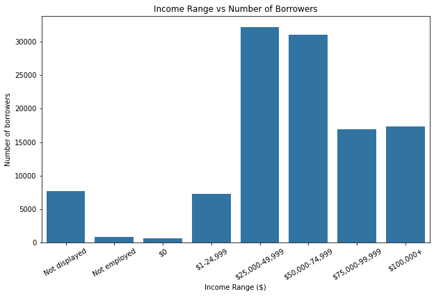

> People who earn between `$25,000- $75,000` make up the largest chunk of borrowers.

## (Visualization 4)

### (Relationship between income range and owning a house)

> Does income range determine whether or not a borrower owns a house or not?

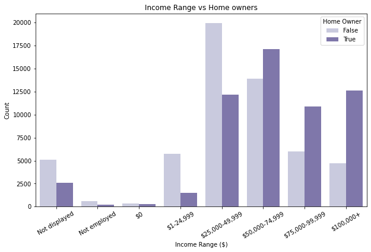

From those earning more i.e 100k+, they are twice more likely to be Home owners and the chart shows that the higher the borrowers earn the more likely that they would be a Home owner, likewise the lesser the borrower earns the less likely that they would be a Home owner.